# Practical Machine Learning - Prediction Assignment

az

Tuesday, December 22, 2015

### Report Background

Using devices such as Jawbone Up, Nike FuelBand, and Fitbit it is now possible to collect a large amount of data about personal activity relatively inexpensively. These type of devices are part of the quantified self movement - a group of enthusiasts who take measurements about themselves regularly to improve their health, to find patterns in their behavior, or because they are tech geeks. One thing that people regularly do is quantify how much of a particular activity they do, but they rarely quantify how well they do it. This report will use data from accelerometers on the belt, forearm, arm, and dumbell of 6 participants who were asked to perform barbell lifts correctly and incorrectly in 5 different ways in order to predict classe variable. More information available from: http://groupware.les.inf.puc-rio.br/har (see the section on Weight lifting exercise dataset).

### Report Summary

1. Download and clean the training and hold out testing data
2. Split the training data further into training and testing subsets
3. Apply cross validation prediction models to training subset and evaluate sample error rates
4. Select model with best accuracy and apply to hold out testing data
5. Predict classe variable for testing data
6. Plot prediction model in appendix
7. Acknowledments to Coursera Data Science community for inspiration to complete this project

```r
#Set working directory and install R packages
setwd("~/Coursera/PML")
library(caret)
```

```r
library(rpart)
library(rpart.plot)
library(randomForest)
```

Download training and test data (performed offline to avoid slow download time delay)

trainUrl <-“http://d396qusza40orc.cloudfront.net/predmachlearn/pml-training.csv”  
testUrl <- “http://d396qusza40orc.cloudfront.net/predmachlearn/pml-testing.csv”  
download.file(trainUrl, destfile=“./pml-training.csv”)  
download.file(testUrl, destfile=“./pml-testing.csv”)

```r
#Read data and verify content
trainRaw <- read.csv("./pml-training.csv")
testRaw <- read.csv("./pml-testing.csv")
dim(trainRaw)
```

```
## [1] 19622   160
```

```r
dim(testRaw)
```

```
## [1]  20 160
```

```r
#Clean the data
#Remove zero and near zero-variance predictors that may cause non tree-based models to crash
n0v <- nearZeroVar(trainRaw, saveMetrics = T)
train <- trainRaw[, !n0v$nzv]

# remove variables with more than 80% missing values
NAv <- sapply(colnames(train), function(x) if(sum(is.na(train[, x])) > 0.8*nrow(train)){return(T)}else{return(F)})
train <- train[, !NAv]

#Remove time and date variables not related to movement activity
classe <- train$classe
trainRemoveTimeDate <- grepl("^X|timestamp|window", names(train))
train <- train[, !trainRemoveTimeDate]
train <- train[, sapply(train, is.numeric)]
train$classe <- classe

testRemoveTimeDate <- grepl("^X|timestamp|window", names(testRaw))
test <- testRaw[, !testRemoveTimeDate]
test <- test[, sapply(test, is.numeric)]
```

The clean training data contains 19622 observations with 53 variables  
The clean testing data contains 20 observations with 53 variables

```r
#create 75%/25% train/test dataset
inTrain <- createDataPartition(train$classe, p=0.75, list=FALSE)
trainData <- train[inTrain, ]
testData <- train[-inTrain, ]
```

```r
#Run Boosting with trees prediction model with gbm option
#Resample with 3 fold cross-validations (to limit processing time)
set.seed(666)
boostFit <- train(classe ~ ., method = "gbm", data = trainData, verbose = F,trControl=trainControl(method="cv",number=3))
boostFit
```

```
## Stochastic Gradient Boosting
##
## 14718 samples
##    52 predictor
##     5 classes: 'A', 'B', 'C', 'D', 'E'
##
## No pre-processing
## Resampling: Cross-Validated (3 fold)
## Summary of sample sizes: 9812, 9812, 9812
## Resampling results across tuning parameters:
##
##   interaction.depth  n.trees  Accuracy   Kappa      Accuracy SD
##   1                   50      0.7505096  0.6837264  0.007785744
##   1                  100      0.8193369  0.7713529  0.003879954
##   1                  150      0.8539204  0.8150779  0.001634897
##   2                   50      0.8554151  0.8167270  0.008593239
##   2                  100      0.9050822  0.8798631  0.001660116
##   2                  150      0.9296779  0.9110140  0.002350706
##   3                   50      0.8964533  0.8688627  0.001776967
##   3                  100      0.9412284  0.9256199  0.000235365
##   3                  150      0.9596413  0.9489388  0.001811699
##   Kappa SD
##   0.0097092317
##   0.0048259813
##   0.0020785416
##   0.0109251063
##   0.0020895179
##   0.0029838571
##   0.0022366094
##   0.0002978378
##   0.0022915618
##
## Tuning parameter 'shrinkage' was held constant at a value of 0.1
##
## Tuning parameter 'n.minobsinnode' was held constant at a value of 10
## Accuracy was used to select the optimal model using  the largest value.
## The final values used for the model were n.trees = 150,
##  interaction.depth = 3, shrinkage = 0.1 and n.minobsinnode = 10.
```

```r
#Apply Boosting model to test data and evaluate accuracy
BoostPredict<-predict(boostFit,testData)
confusionMatrix(testData$classe,BoostPredict)
```

```
## Confusion Matrix and Statistics
##
##           Reference
## Prediction    A    B    C    D    E
##          A 1369   20    3    3    0
##          B   26  888   35    0    0
##          C    0   24  821    9    1
##          D    0    3   26  768    7
##          E    0   13    7    9  872
##
## Overall Statistics
##
##                Accuracy : 0.9621
##                  95% CI : (0.9563, 0.9672)
##     No Information Rate : 0.2845
##     P-Value [Acc > NIR] : < 2.2e-16
##
##                   Kappa : 0.952
##  Mcnemar's Test P-Value : NA
##
## Statistics by Class:
##
##                      Class: A Class: B Class: C Class: D Class: E
## Sensitivity            0.9814   0.9367   0.9204   0.9734   0.9909
## Specificity            0.9926   0.9846   0.9915   0.9913   0.9928
## Pos Pred Value         0.9814   0.9357   0.9602   0.9552   0.9678
## Neg Pred Value         0.9926   0.9848   0.9825   0.9949   0.9980
## Prevalence             0.2845   0.1933   0.1819   0.1609   0.1794
## Detection Rate         0.2792   0.1811   0.1674   0.1566   0.1778
## Detection Prevalence   0.2845   0.1935   0.1743   0.1639   0.1837
## Balanced Accuracy      0.9870   0.9606   0.9560   0.9823   0.9919
```

```r
B_accuracy <- postResample(BoostPredict, testData$classe)
paste("Boosting model accuracy: ",round(B_accuracy[1]*100,2),"%  ",
      "out of sample error: ",round((1-B_accuracy[1])*100,2),"%")
```

```
## [1] "Boosting model accuracy:  96.21 %   out of sample error:  3.79 %"
```

```r
#Run Random Forest prediction model
#Resample with 3 fold cross-validations (to limit processing time)
set.seed(666)
rf <- train(classe ~ .,method="rf",data=trainData,trControl=trainControl(method="cv",number=3),ntree=150)
rf
```

```
## Random Forest
##
## 14718 samples
##    52 predictor
##     5 classes: 'A', 'B', 'C', 'D', 'E'
##
## No pre-processing
## Resampling: Cross-Validated (3 fold)
## Summary of sample sizes: 9812, 9812, 9812
## Resampling results across tuning parameters:
##
##   mtry  Accuracy   Kappa      Accuracy SD  Kappa SD
##    2    0.9875662  0.9842680  0.000203832  0.0002556868
##   27    0.9887892  0.9858172  0.001078578  0.0013650014
##   52    0.9792091  0.9736958  0.003477114  0.0044013714
##
## Accuracy was used to select the optimal model using  the largest value.
## The final value used for the model was mtry = 27.
```

```r
#Apply Random Forest model to test data and evaluate accuracy
RFPredict<-predict(rf,testData)
confusionMatrix(testData$classe,RFPredict)
```

```
## Confusion Matrix and Statistics
##
##           Reference
## Prediction    A    B    C    D    E
##          A 1393    2    0    0    0
##          B    5  942    2    0    0
##          C    0    2  847    6    0
##          D    0    1    7  796    0
##          E    0    2    1    1  897
##
## Overall Statistics
##
##                Accuracy : 0.9941
##                  95% CI : (0.9915, 0.996)
##     No Information Rate : 0.2851
##     P-Value [Acc > NIR] : < 2.2e-16
##
##                   Kappa : 0.9925
##  Mcnemar's Test P-Value : NA
##
## Statistics by Class:
##
##                      Class: A Class: B Class: C Class: D Class: E
## Sensitivity            0.9964   0.9926   0.9883   0.9913   1.0000
## Specificity            0.9994   0.9982   0.9980   0.9980   0.9990
## Pos Pred Value         0.9986   0.9926   0.9906   0.9900   0.9956
## Neg Pred Value         0.9986   0.9982   0.9975   0.9983   1.0000
## Prevalence             0.2851   0.1935   0.1748   0.1637   0.1829
## Detection Rate         0.2841   0.1921   0.1727   0.1623   0.1829
## Detection Prevalence   0.2845   0.1935   0.1743   0.1639   0.1837
## Balanced Accuracy      0.9979   0.9954   0.9932   0.9947   0.9995
```

```r
RF_accuracy <- postResample(RFPredict, testData$classe)
paste("Random Forest model accuracy: ",round(RF_accuracy[1]*100,2),"%  ",
      "out of sample error: ",round((1-RF_accuracy[1])*100,2),"%")
```

```
## [1] "Random Forest model accuracy:  99.41 %   out of sample error:  0.59 %"
```

Two prediction models were applied to the training subset data.  
Both models were resampled with 3 fold cross-validation to limit processing time.  
Boosting model gave accuracy of 96% and out of sample error of 4%.  
Random Forest model gave better accuracy of 99% and out of sample error of 1% and is selected to predict project test case answers from the hold out test data.

```r
#Predict on test to answer project test cases
answers=(RFPrediction <- as.character(predict(rf, test)))
answers
```

```
##  [1] "B" "A" "B" "A" "A" "E" "D" "B" "A" "A" "B" "C" "B" "A" "E" "E" "A"
## [18] "B" "B" "B"
```

### Appendix

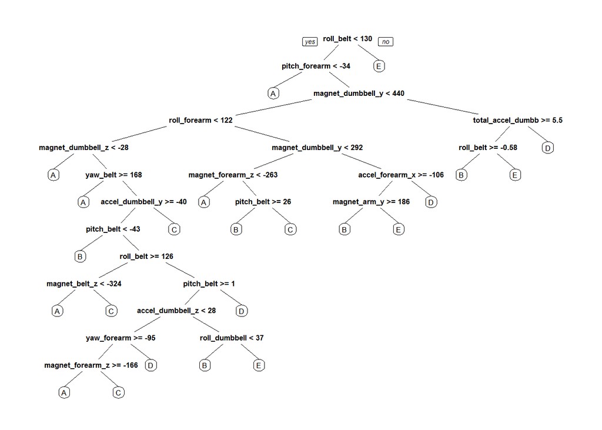